[OHI-Northeast](http://www.ohi-northeast.org/) | [OHI Science](http://ohi-science.org) | [Citation policy](http://ohi-science.org/citation-policy/)

# OHIEC: Resilience - Water Pollution

Compiled on Wed Jul 17 15:53:36 2019 by verstaen

# Summary

This script calculates water pollution resilience values by OHINE region.

# Data

**Reference**: EPA ECHO database https://echo.epa.gov/tools/data-downloads

1. ICIS-NPDES National Data Set
1. ICIS_FACILITIES.csv
2. NPDES_INSPECTIONS.csv
3. NPDES_QNCR_HISTORY.csv
2. Permit Limit and DMR Data by Jurisdiction

**Downloaded**: July, 2019

**Description**:

4 metrics included in the calculation: 1. Presence or absence of water discharge regulation 2. Score between 0-1 for inspections of discharge facilities 3. Score between 0-1 for discharge facilitiy violation 4. Score between 0-1 for submissions of discharge monitoring reports (DMR)

Target = EPA established ‘National Goals’: 1. 50% for inspector coverage 2. 95% for monitoring report submission (DMR) 3. 0% for compliance violations.

**Time range**: Data provided annually for each source

1. ICIS-NPDES National Data Set
1. ICIS_FACILITIES.csv: no date range
2. NPDES_INSPECTIONS.csv: 1967-2019
3. NPDES_QNCR_HISTORY.csv:1973-2019
2. Permit Limit and DMR Data by Jurisdiction: 2009-2019

**Format**: CSV file

```r
knitr::opts_chunk$set(fig.width = 6, fig.height = 4, fig.path = 'figs/',
                      message = FALSE, warning = FALSE)

source('~/github/ne-prep/src/R/common.R')  ### an OHINE specific version of common.R

dir_git <- '~/github/ne-prep'
dir_anx <- file.path(dir_M, 'git-annex/neprep')

library(csv)
library(dplyr)
library(tidyverse)
```

#Data

```r
raw_inspec <- read_csv(file.path(dir_anx, "_raw_data/EPA_ECHO/NPDES_INSPECTIONS.csv"))
raw_report_history <- read_csv(file.path(dir_anx, "_raw_data/EPA_ECHO/NPDES_QNCR_HISTORY.csv"))
raw_facilities <- read_csv(file.path(dir_anx, "_raw_data/EPA_ECHO/ICIS_FACILITIES.csv"))

#all the state annual DMRs
#2009
raw_maine_2009 <- read_csv(file.path(dir_anx, "_raw_data/EPA_ECHO/DMR_Annual/2009/maine/ME_FY2009_NPDES_DMRS.csv"))
raw_connecticut_2009 <- read_csv(file.path(dir_anx, "_raw_data/EPA_ECHO/DMR_Annual/2009/connecticut/CT_FY2009_NPDES_DMRS.csv"))
raw_massachusetts_2009 <- read_csv(file.path(dir_anx, "_raw_data/EPA_ECHO/DMR_Annual/2009/massachusets/MA_FY2009_NPDES_DMRS.csv"))
raw_newhampshire_2009 <- read_csv(file.path(dir_anx, "_raw_data/EPA_ECHO/DMR_Annual/2009/new_hampshire/NH_FY2009_NPDES_DMRS.csv"))
raw_newyork_2009 <- read_csv(file.path(dir_anx, "_raw_data/EPA_ECHO/DMR_Annual/2009/new_york/NY_FY2009_NPDES_DMRS.csv"))
raw_rhodeisland_2009 <- read_csv(file.path(dir_anx, "_raw_data/EPA_ECHO/DMR_Annual/2009/rhode_island/RI_FY2009_NPDES_DMRS.csv"))

#2010
raw_maine_2010 <- read_csv(file.path(dir_anx, "_raw_data/EPA_ECHO/DMR_Annual/2010/maine/ME_FY2010_NPDES_DMRS.csv"))
raw_connecticut_2010 <- read_csv(file.path(dir_anx, "_raw_data/EPA_ECHO/DMR_Annual/2010/connecticut/CT_FY2010_NPDES_DMRS.csv"))
raw_massachusetts_2010 <- read_csv(file.path(dir_anx, "_raw_data/EPA_ECHO/DMR_Annual/2010/massachusetts/MA_FY2010_NPDES_DMRS.csv"))
raw_newhampshire_2010 <- read_csv(file.path(dir_anx, "_raw_data/EPA_ECHO/DMR_Annual/2010/new_hampshire/NH_FY2010_NPDES_DMRS.csv"))
raw_newyork_2010 <- read_csv(file.path(dir_anx, "_raw_data/EPA_ECHO/DMR_Annual/2010/new_york/NY_FY2010_NPDES_DMRS.csv"))
raw_rhodeisland_2010 <- read_csv(file.path(dir_anx, "_raw_data/EPA_ECHO/DMR_Annual/2010/rhode_island/RI_FY2010_NPDES_DMRS.csv"))

#2011
raw_maine_2011 <- read_csv(file.path(dir_anx, "_raw_data/EPA_ECHO/DMR_Annual/2011/maine/ME_FY2011_NPDES_DMRS.csv"))
raw_connecticut_2011 <- read_csv(file.path(dir_anx, "_raw_data/EPA_ECHO/DMR_Annual/2011/connecticut/CT_FY2011_NPDES_DMRS.csv"))
raw_massachusetts_2011 <- read_csv(file.path(dir_anx, "_raw_data/EPA_ECHO/DMR_Annual/2011/massachusetts/MA_FY2011_NPDES_DMRS.csv"))
raw_newhampshire_2011 <- read_csv(file.path(dir_anx, "_raw_data/EPA_ECHO/DMR_Annual/2011/new_hampshire/NH_FY2011_NPDES_DMRS.csv"))
raw_newyork_2011 <- read_csv(file.path(dir_anx, "_raw_data/EPA_ECHO/DMR_Annual/2011/new_york/NY_FY2011_NPDES_DMRS.csv"))
raw_rhodeisland_2011 <- read_csv(file.path(dir_anx, "_raw_data/EPA_ECHO/DMR_Annual/2011/rhode_island/RI_FY2011_NPDES_DMRS.csv"))

#2012
raw_maine_2012 <- read_csv(file.path(dir_anx, "_raw_data/EPA_ECHO/DMR_Annual/2012/maine/ME_FY2012_NPDES_DMRS.csv"))
raw_connecticut_2012 <- read_csv(file.path(dir_anx, "_raw_data/EPA_ECHO/DMR_Annual/2012/connecticut/CT_FY2012_NPDES_DMRS.csv"))
raw_massachusetts_2012 <- read_csv(file.path(dir_anx, "_raw_data/EPA_ECHO/DMR_Annual/2012/massachusetts/MA_FY2012_NPDES_DMRS.csv"))
raw_newhampshire_2012 <- read_csv(file.path(dir_anx, "_raw_data/EPA_ECHO/DMR_Annual/2012/new_hampshire/NH_FY2012_NPDES_DMRS.csv"))
raw_newyork_2012 <- read_csv(file.path(dir_anx, "_raw_data/EPA_ECHO/DMR_Annual/2012/new_york/NY_FY2012_NPDES_DMRS.csv"))
raw_rhodeisland_2012 <- read_csv(file.path(dir_anx, "_raw_data/EPA_ECHO/DMR_Annual/2012/rhode_island/RI_FY2012_NPDES_DMRS.csv"))

#2013
raw_maine_2013 <- read_csv(file.path(dir_anx, "_raw_data/EPA_ECHO/DMR_Annual/2013/maine/ME_FY2013_NPDES_DMRS.csv"))
raw_connecticut_2013 <- read_csv(file.path(dir_anx, "_raw_data/EPA_ECHO/DMR_Annual/2013/connecticut/CT_FY2013_NPDES_DMRS.csv"))
raw_massachusetts_2013 <- read_csv(file.path(dir_anx, "_raw_data/EPA_ECHO/DMR_Annual/2013/massachusetts/MA_FY2013_NPDES_DMRS.csv"))
raw_newhampshire_2013 <- read_csv(file.path(dir_anx, "_raw_data/EPA_ECHO/DMR_Annual/2013/new_hampshire/NH_FY2013_NPDES_DMRS.csv"))
raw_newyork_2013 <- read_csv(file.path(dir_anx, "_raw_data/EPA_ECHO/DMR_Annual/2013/new_york/NY_FY2013_NPDES_DMRS.csv"))
raw_rhodeisland_2013 <- read_csv(file.path(dir_anx, "_raw_data/EPA_ECHO/DMR_Annual/2013/rhode_island/RI_FY2013_NPDES_DMRS.csv"))

#2014
raw_maine_2014 <- read_csv(file.path(dir_anx, "_raw_data/EPA_ECHO/DMR_Annual/2014/maine/ME_FY2014_NPDES_DMRS.csv"))
raw_connecticut_2014 <- read_csv(file.path(dir_anx, "_raw_data/EPA_ECHO/DMR_Annual/2014/connecticut/CT_FY2014_NPDES_DMRS.csv"))
raw_massachusetts_2014 <- read_csv(file.path(dir_anx, "_raw_data/EPA_ECHO/DMR_Annual/2014/massachusetts/MA_FY2014_NPDES_DMRS.csv"))
raw_newhampshire_2014 <- read_csv(file.path(dir_anx, "_raw_data/EPA_ECHO/DMR_Annual/2014/new_hampshire/NH_FY2014_NPDES_DMRS.csv"))
raw_newyork_2014 <- read_csv(file.path(dir_anx, "_raw_data/EPA_ECHO/DMR_Annual/2014/new_york/NY_FY2014_NPDES_DMRS.csv"))
raw_rhodeisland_2014 <- read_csv(file.path(dir_anx, "_raw_data/EPA_ECHO/DMR_Annual/2014/rhode_island/RI_FY2014_NPDES_DMRS.csv"))


#2015
raw_maine_2015 <- read_csv(file.path(dir_anx, "_raw_data/EPA_ECHO/DMR_Annual/2015/maine/ME_FY2015_NPDES_DMRS.csv"))
raw_connecticut_2015 <- read_csv(file.path(dir_anx, "_raw_data/EPA_ECHO/DMR_Annual/2015/connecticut/CT_FY2015_NPDES_DMRS.csv"))
raw_massachusetts_2015 <- read_csv(file.path(dir_anx, "_raw_data/EPA_ECHO/DMR_Annual/2015/massachusetts/MA_FY2015_NPDES_DMRS.csv"))
raw_newhampshire_2015 <- read_csv(file.path(dir_anx, "_raw_data/EPA_ECHO/DMR_Annual/2015/new_hampshire/NH_FY2015_NPDES_DMRS.csv"))
raw_newyork_2015 <- read_csv(file.path(dir_anx, "_raw_data/EPA_ECHO/DMR_Annual/2015/new_york/NY_FY2015_NPDES_DMRS.csv"))
raw_rhodeisland_2015 <- read_csv(file.path(dir_anx, "_raw_data/EPA_ECHO/DMR_Annual/2015/rhode_island/RI_FY2015_NPDES_DMRS.csv"))

#2016
raw_maine_2016 <- read_csv(file.path(dir_anx, "_raw_data/EPA_ECHO/DMR_Annual/2016/maine/ME_FY2016_NPDES_DMRS.csv"))
raw_connecticut_2016 <- read_csv(file.path(dir_anx, "_raw_data/EPA_ECHO/DMR_Annual/2016/connecticut/CT_FY2016_NPDES_DMRS.csv"))
raw_massachusetts_2016 <- read_csv(file.path(dir_anx, "_raw_data/EPA_ECHO/DMR_Annual/2016/massachusetts/MA_FY2016_NPDES_DMRS.csv"))
raw_newhampshire_2016 <- read_csv(file.path(dir_anx, "_raw_data/EPA_ECHO/DMR_Annual/2016/new_hampshire/NH_FY2016_NPDES_DMRS.csv"))
raw_newyork_2016 <- read_csv(file.path(dir_anx, "_raw_data/EPA_ECHO/DMR_Annual/2016/new_york/NY_FY2016_NPDES_DMRS.csv"))
raw_rhodeisland_2016 <- read_csv(file.path(dir_anx, "_raw_data/EPA_ECHO/DMR_Annual/2016/rhode_island/RI_FY2016_NPDES_DMRS.csv"))


#2017
raw_maine_2017 <- read_csv(file.path(dir_anx, "_raw_data/EPA_ECHO/DMR_Annual/2017/maine/ME_FY2017_NPDES_DMRS.csv"))
raw_connecticut_2017 <- read_csv(file.path(dir_anx, "_raw_data/EPA_ECHO/DMR_Annual/2017/connecticut/CT_FY2017_NPDES_DMRS.csv"))
raw_massachusetts_2017 <- read_csv(file.path(dir_anx, "_raw_data/EPA_ECHO/DMR_Annual/2017/massachusetts/MA_FY2017_NPDES_DMRS.csv"))
raw_newhampshire_2017 <- read_csv(file.path(dir_anx, "_raw_data/EPA_ECHO/DMR_Annual/2017/new_hampshire/NH_FY2017_NPDES_DMRS.csv"))
raw_newyork_2017 <- read_csv(file.path(dir_anx, "_raw_data/EPA_ECHO/DMR_Annual/2017/new_york/NY_FY2017_NPDES_DMRS.csv"))
raw_rhodeisland_2017 <- read_csv(file.path(dir_anx, "_raw_data/EPA_ECHO/DMR_Annual/2017/rhode_island/RI_FY2017_NPDES_DMRS.csv"))
```

#Methods

##**Monitoring** ###Inspections

```r
inspec <- raw_inspec %>%
  select(NPDES_ID, ACTUAL_END_DATE) %>% #choose end instead of start because many NAs in "ACTUAL_START_DATE" and not in end
  separate(ACTUAL_END_DATE, c("month", "day", "year"), sep = "/") %>%
  select(NPDES_ID, year)%>%
  filter(year >=2005 & year <=2017) %>%
  distinct() %>% # just want to know if the facility had been inspected that year, doesn't matter if it was more than once
  mutate(inspec = "1") %>%  # yes(1) or no(0) there was an inspection
  select(NPDES_ID, year, inspec)
```

```r
fac <- raw_facilities %>%
  select(NPDES_ID) %>%
  mutate("2005" = "2005") %>% # creating a list of all the facilities for each year during our time range
  mutate("2006" = "2006") %>%
  mutate("2007" = "2007") %>%
  mutate("2008" = "2008") %>%
  mutate("2009" = "2009") %>%
  mutate("2010" = "2010") %>%
  mutate("2011" = "2011") %>%
  mutate("2012" = "2012") %>%
  mutate("2013" = "2013") %>%
  mutate("2014" = "2014") %>%
  mutate("2015" = "2015") %>%
  mutate("2016" = "2016") %>%
  mutate("2017" = "2017") %>%
  gather(year, year2, 2:14) %>%
  select(NPDES_ID, year)%>%
  mutate(state = substr(NPDES_ID, 0, 2))
```

```r
inspections_clean <- left_join(fac, inspec, by = c("NPDES_ID", "year")) %>%
  replace(., is.na(.), "0") %>%
  mutate(state = substr(NPDES_ID, 0, 2)) %>%
  filter(state == "ME" | state == "NH" | state == "MA" | state =="RI" | state == "CT" | state == "NY")
```

inspections stats

```r
#total number of facilities in each state: should be the same every year since used the meta data of all facilities. Could improve this by finding a list of facilities each year to account for some going out of business and new ones arriving

num_fac <- fac %>%
  select(state, year, NPDES_ID) %>%
  filter(state == "ME" | state == "NH" | state == "MA" | state =="RI" | state == "CT" | state == "NY") %>%
  distinct() %>%
  group_by(year, state) %>%
  tally() %>%
  ungroup() %>%
  rename(fac_total = n)
```

```r
#total number of facilities inspected at least once that year by state
num_fac_inspec <- inspections_clean %>%
  filter(inspec == 1) %>%
  select(state, year, NPDES_ID) %>%
  group_by(year, state) %>%
  count() %>%
  ungroup() %>%
  rename(fac_inspection = n)
```

Merging and writing tidy csv

```r
facilities_inspected <- left_join(num_fac, num_fac_inspec, by = c("year", "state")) %>%
  mutate(percent_w_inspections = fac_inspection/fac_total,
         year = as.numeric(year))

##save file
#write.csv(facilities_inspected, "data/facilities_inspected.csv")
```

Visualization

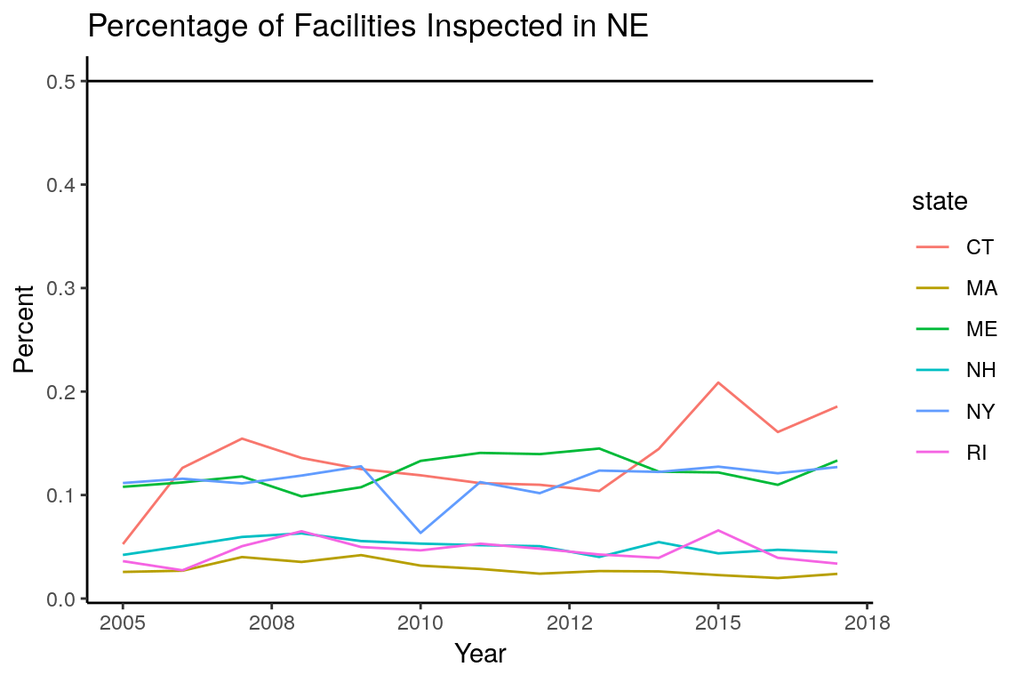

```r
inspections_graph <- ggplot(facilities_inspected) +
  geom_line(aes(x= year, y = percent_w_inspections, color= state))+
 ggtitle("Percentage of Facilities Inspected in NE") +
  ylab("Percent") +
  xlab("Year") +
  theme_classic()+
  geom_hline(yintercept=0.5)
inspections_graph
```

```r
##save fig
#ggsave("figs/inspections_graph.jpg", width=7, height=5, dpi=300)
```

###Report Submissions

RNC_DETECTION_CODE: N = Non-Recipt of DMR/Schedule Report

2009

```r
## Maine
maine_2009_sub <- raw_maine_2009 %>%
  select(EXTERNAL_PERMIT_NMBR, RNC_DETECTION_CODE) %>%
  filter(RNC_DETECTION_CODE == "N")

ME_2009 <- 1-(count(maine_2009_sub)/count(raw_maine_2009))
#expected 85510 reports
#did not receive 2832
#0.9668811 received

## New Hampshire
newhampshire_2009_sub <- raw_newhampshire_2009 %>%
  select(EXTERNAL_PERMIT_NMBR, RNC_DETECTION_CODE) %>%
  filter(RNC_DETECTION_CODE == "N")

NH_2009 <- 1-(count(newhampshire_2009_sub)/count(raw_newhampshire_2009))
    #expected 40841 reports
    #did not receive 115
    #0.9971842 received

## Massachusetts
massachusetts_2009_sub <- raw_massachusetts_2009 %>%
  select(EXTERNAL_PERMIT_NMBR, RNC_DETECTION_CODE) %>%
  filter(RNC_DETECTION_CODE == "N")

MA_2009 <- 1-(count(massachusetts_2009_sub)/count(raw_massachusetts_2009))
#expected 102756 reports
# did not receive 1626
#0.9841761 received


## Rhode Island
rhodeisland_2009_sub <- raw_rhodeisland_2009 %>%
  select(EXTERNAL_PERMIT_NMBR, RNC_DETECTION_CODE) %>%
  filter(RNC_DETECTION_CODE == "N")

RI_2009 <- 1-(count(rhodeisland_2009_sub)/count(raw_rhodeisland_2009))
#expected 45477 reports
# did not receive 0
#1 received

## Connecticut
connecticut_2009_sub <- raw_connecticut_2009 %>%
  select(EXTERNAL_PERMIT_NMBR, RNC_DETECTION_CODE) %>%
  filter(RNC_DETECTION_CODE == "N")

CT_2009 <- 1-(count(connecticut_2009_sub)/count(raw_connecticut_2009))
#expected 130445 reports
# did not receive 0
#1 received


## New York
newyork_2009_sub <- raw_newyork_2009 %>%
  select(EXTERNAL_PERMIT_NMBR, RNC_DETECTION_CODE) %>%
  filter(RNC_DETECTION_CODE == "N")

NY_2009 <- 1-(count(newyork_2009_sub)/count(raw_newyork_2009))
#expected 517016 reports
# did not receive 1380
#0.9973308 received
```

2010

```r
## Maine
maine_2010_sub <- raw_maine_2010 %>%
  select(EXTERNAL_PERMIT_NMBR, RNC_DETECTION_CODE) %>%
  filter(RNC_DETECTION_CODE == "N")

ME_2010 <- 1-(count(maine_2010_sub)/count(raw_maine_2010))
#expected 82388 reports
# did not receive 2311
#0.9719498 received


## New Hampshire
newhampshire_2010_sub <- raw_newhampshire_2010 %>%
  select(EXTERNAL_PERMIT_NMBR, RNC_DETECTION_CODE) %>%
  filter(RNC_DETECTION_CODE == "N")

NH_2010 <- 1-(count(newhampshire_2010_sub)/count(raw_newhampshire_2010))
#expected 40820 reports
# did not receive 99
#0.9975747 received

## Massachusetts
massachusetts_2010_sub <- raw_massachusetts_2010 %>%
  select(EXTERNAL_PERMIT_NMBR, RNC_DETECTION_CODE) %>%
  filter(RNC_DETECTION_CODE == "N")

MA_2010 <- 1-(count(massachusetts_2010_sub)/count(raw_massachusetts_2010))
#expected 103549 reports
# did not receive 0
#1 received


## Rhode Island
rhodeisland_2010_sub <- raw_rhodeisland_2010 %>%
  select(EXTERNAL_PERMIT_NMBR, RNC_DETECTION_CODE) %>%
  filter(RNC_DETECTION_CODE == "N")

RI_2010 <- 1-(count(rhodeisland_2010_sub)/count(raw_rhodeisland_2010))
#expected 45642 reports
# did not receive 0
#1 received

## Connecticut
connecticut_2010_sub <- raw_connecticut_2010 %>%
  select(EXTERNAL_PERMIT_NMBR, RNC_DETECTION_CODE) %>%
  filter(RNC_DETECTION_CODE == "N")

CT_2010 <- 1-(count(connecticut_2010_sub)/count(raw_connecticut_2010))
#expected 128342 reports
# did not receive 0
#1 received


## New York
newyork_2010_sub <- raw_newyork_2010 %>%
  select(EXTERNAL_PERMIT_NMBR, RNC_DETECTION_CODE) %>%
  filter(RNC_DETECTION_CODE == "N")

NY_2010 <- 1-(count(newyork_2010_sub)/count(raw_newyork_2010))
#expected 523307 reports
# did not receive 1610
#0.9969234 received
```

2011

```r
## Maine
maine_2011_sub <- raw_maine_2011 %>%
  select(EXTERNAL_PERMIT_NMBR, RNC_DETECTION_CODE) %>%
  filter(RNC_DETECTION_CODE == "N")

ME_2011 <- 1-(count(maine_2011_sub)/count(raw_maine_2011))
#expected 82716 reports
# did not receive 1367
#0.9834736 received


## New Hampshire
newhampshire_2011_sub <- raw_newhampshire_2011 %>%
  select(EXTERNAL_PERMIT_NMBR, RNC_DETECTION_CODE) %>%
  filter(RNC_DETECTION_CODE == "N")

NH_2011 <- 1-(count(newhampshire_2011_sub)/count(raw_newhampshire_2011))
#expected 40210 reports
# did not receive 0
#0.9975747 received

## Massachusetts
massachusetts_2011_sub <- raw_massachusetts_2011 %>%
  select(EXTERNAL_PERMIT_NMBR, RNC_DETECTION_CODE) %>%
  filter(RNC_DETECTION_CODE == "N")

MA_2011 <- 1-(count(massachusetts_2011_sub)/count(raw_massachusetts_2011))
#expected 103150 reports
# did not receive 0
#1 received


## Rhode Island
rhodeisland_2011_sub <- raw_rhodeisland_2011 %>%
  select(EXTERNAL_PERMIT_NMBR, RNC_DETECTION_CODE) %>%
  filter(RNC_DETECTION_CODE == "N")

RI_2011 <- 1-(count(rhodeisland_2011_sub)/count(raw_rhodeisland_2011))
#expected 46621 reports
# did not receive 0
#1 received

## Connecticut
connecticut_2011_sub <- raw_connecticut_2011 %>%
  select(EXTERNAL_PERMIT_NMBR, RNC_DETECTION_CODE) %>%
  filter(RNC_DETECTION_CODE == "N")

CT_2011 <- 1-(count(connecticut_2011_sub)/count(raw_connecticut_2011))
#expected 128656 reports
# did not receive 0
#1 received


## New York
newyork_2011_sub <- raw_newyork_2011 %>%
  select(EXTERNAL_PERMIT_NMBR, RNC_DETECTION_CODE) %>%
  filter(RNC_DETECTION_CODE == "N")

NY_2011 <- 1-(count(newyork_2011_sub)/count(raw_newyork_2011))
#expected 534640 reports
# did not receive 1492
#0.9972093 received
```

2012

```r
## Maine
maine_2012_sub <- raw_maine_2012 %>%
  select(EXTERNAL_PERMIT_NMBR, RNC_DETECTION_CODE) %>%
  filter(RNC_DETECTION_CODE == "N")

#expected 80818 reports
# did not receive 695
ME_2012 <- 1-(count(maine_2012_sub)/count(raw_maine_2012))
#0.9914004 received


## New Hampshire
newhampshire_2012_sub <- raw_newhampshire_2012 %>%
  select(EXTERNAL_PERMIT_NMBR, RNC_DETECTION_CODE) %>%
  filter(RNC_DETECTION_CODE == "N")

NH_2012 <- 1-(count(newhampshire_2012_sub)/count(raw_newhampshire_2012))
#expected 42033 reports
# did not receive 0
#0.9975747 received

## Massachusetts
massachusetts_2012_sub <- raw_massachusetts_2012 %>%
  select(EXTERNAL_PERMIT_NMBR, RNC_DETECTION_CODE) %>%
  filter(RNC_DETECTION_CODE == "N")

MA_2012 <- 1-(count(massachusetts_2012_sub)/count(raw_massachusetts_2012))
#expected 103575 reports
# did not receive 1477
#0.9857398 received


## Rhode Island
rhodeisland_2012_sub <- raw_rhodeisland_2012 %>%
  select(EXTERNAL_PERMIT_NMBR, RNC_DETECTION_CODE) %>%
  filter(RNC_DETECTION_CODE == "N")

RI_2012 <- 1-(count(rhodeisland_2012_sub)/count(raw_rhodeisland_2012))
#expected 42751 reports
# did not receive 0
#1 received

## Connecticut
connecticut_2012_sub <- raw_connecticut_2012 %>%
  select(EXTERNAL_PERMIT_NMBR, RNC_DETECTION_CODE) %>%
  filter(RNC_DETECTION_CODE == "N")

CT_2012 <- 1-(count(connecticut_2012_sub)/count(raw_connecticut_2012))
#expected 127430 reports
# did not receive 0
#1 received


## New York
newyork_2012_sub <- raw_newyork_2012 %>%
  select(EXTERNAL_PERMIT_NMBR, RNC_DETECTION_CODE) %>%
  filter(RNC_DETECTION_CODE == "N")

NY_2012 <- 1-(count(newyork_2012_sub)/count(raw_newyork_2012))
#expected 544661 reports
# did not receive 1864
#0.9965777 received
```

2013

```r
## Maine
maine_2013_sub <- raw_maine_2013 %>%
  select(EXTERNAL_PERMIT_NMBR, RNC_DETECTION_CODE) %>%
  filter(RNC_DETECTION_CODE == "N")

#expected 82573 reports
# did not receive 424
ME_2013 <- 1-(count(maine_2013_sub)/count(raw_maine_2013))
#0.9948651 received


## New Hampshire
newhampshire_2013_sub <- raw_newhampshire_2013 %>%
  select(EXTERNAL_PERMIT_NMBR, RNC_DETECTION_CODE) %>%
  filter(RNC_DETECTION_CODE == "N")

#expected 43505 reports
# did not receive 0
NH_2013 <- 1-(count(newhampshire_2013_sub)/count(raw_newhampshire_2013))
#0.9975747 received

## Massachusetts
massachusetts_2013_sub <- raw_massachusetts_2013 %>%
  select(EXTERNAL_PERMIT_NMBR, RNC_DETECTION_CODE) %>%
  filter(RNC_DETECTION_CODE == "N")

#expected 105635 reports
# did not receive 0
MA_2013 <- 1-(count(massachusetts_2013_sub)/count(raw_massachusetts_2013))
#0.9857398 received


## Rhode Island
rhodeisland_2013_sub <- raw_rhodeisland_2013 %>%
  select(EXTERNAL_PERMIT_NMBR, RNC_DETECTION_CODE) %>%
  filter(RNC_DETECTION_CODE == "N")

#expected 37956 reports
# did not receive 0
RI_2013 <- 1-(count(rhodeisland_2013_sub)/count(raw_rhodeisland_2013))
#1 received

## Connecticut
connecticut_2013_sub <- raw_connecticut_2013 %>%
  select(EXTERNAL_PERMIT_NMBR, RNC_DETECTION_CODE) %>%
  filter(RNC_DETECTION_CODE == "N")

#expected 129114 reports
# did not receive 920
CT_2013 <- 1-(count(connecticut_2013_sub)/count(raw_connecticut_2013))
#0.9928745 received


## New York
newyork_2013_sub <- raw_newyork_2013 %>%
  select(EXTERNAL_PERMIT_NMBR, RNC_DETECTION_CODE) %>%
  filter(RNC_DETECTION_CODE == "N")

#expected 545149 reports
# did not receive 2230
NY_2013 <- 1-(count(newyork_2013_sub)/count(raw_newyork_2013))
#0.9959094 received
```

2014

```r
## Maine
maine_2014_sub <- raw_maine_2014 %>%
  select(EXTERNAL_PERMIT_NMBR, RNC_DETECTION_CODE) %>%
  filter(RNC_DETECTION_CODE == "N")

#expected 82143 reports
# did not receive 238
ME_2014 <- 1-(count(maine_2014_sub)/count(raw_maine_2014))
#0.9971026 received


## New Hampshire
newhampshire_2014_sub <- raw_newhampshire_2014 %>%
  select(EXTERNAL_PERMIT_NMBR, RNC_DETECTION_CODE) %>%
  filter(RNC_DETECTION_CODE == "N")

#expected 43494 reports
# did not receive 0
NH_2014 <- 1-(count(newhampshire_2014_sub)/count(raw_newhampshire_2014))
#0.9975747 received

## Massachusetts
massachusetts_2014_sub <- raw_massachusetts_2014 %>%
  select(EXTERNAL_PERMIT_NMBR, RNC_DETECTION_CODE) %>%
  filter(RNC_DETECTION_CODE == "N")

#expected 108101 reports
# did not receive 1245
MA_2014 <- 1-(count(massachusetts_2014_sub)/count(raw_massachusetts_2014))
#0.988483 received


## Rhode Island
rhodeisland_2014_sub <- raw_rhodeisland_2014 %>%
  select(EXTERNAL_PERMIT_NMBR, RNC_DETECTION_CODE) %>%
  filter(RNC_DETECTION_CODE == "N")

#expected 34257 reports
# did not receive 1032
RI_2014 <- 1-(count(rhodeisland_2014_sub)/count(raw_rhodeisland_2014))
#0.9698748 received

## Connecticut
connecticut_2014_sub <- raw_connecticut_2014 %>%
  select(EXTERNAL_PERMIT_NMBR, RNC_DETECTION_CODE) %>%
  filter(RNC_DETECTION_CODE == "N")

#expected 132920 reports
# did not receive 1280
CT_2014 <- 1-(count(connecticut_2014_sub)/count(raw_connecticut_2014))
#0.9903701 received


## New York
newyork_2014_sub <- raw_newyork_2014 %>%
  select(EXTERNAL_PERMIT_NMBR, RNC_DETECTION_CODE) %>%
  filter(RNC_DETECTION_CODE == "N")

#expected 545446 reports
# did not receive 2140
NY_2014 <- 1-(count(newyork_2014_sub)/count(raw_newyork_2014))
#0.9959094 received
```

2015

```r
## Maine
maine_2015_sub <- raw_maine_2015 %>%
  select(EXTERNAL_PERMIT_NMBR, RNC_DETECTION_CODE) %>%
  filter(RNC_DETECTION_CODE == "N")

#expected 81137 reports
# did not receive 344
ME_2015 <- 1-(count(maine_2015_sub)/count(raw_maine_2015))
#0.9957603 received


## New Hampshire
newhampshire_2015_sub <- raw_newhampshire_2015 %>%
  select(EXTERNAL_PERMIT_NMBR, RNC_DETECTION_CODE) %>%
  filter(RNC_DETECTION_CODE == "N")

#expected 41484 reports
# did not receive 0
NH_2015 <- 1-(count(newhampshire_2015_sub)/count(raw_newhampshire_2015))
#0.9975747 received

## Massachusetts
massachusetts_2015_sub <- raw_massachusetts_2015 %>%
  select(EXTERNAL_PERMIT_NMBR, RNC_DETECTION_CODE) %>%
  filter(RNC_DETECTION_CODE == "N")

#expected 110400 reports
# did not receive 1494
MA_2015 <- 1-(count(massachusetts_2015_sub)/count(raw_massachusetts_2015))
#0.988483 received


## Rhode Island
rhodeisland_2015_sub <- raw_rhodeisland_2015 %>%
  select(EXTERNAL_PERMIT_NMBR, RNC_DETECTION_CODE) %>%
  filter(RNC_DETECTION_CODE == "N")

#expected 34740 reports
# did not receive 1096
RI_2015 <- 1-(count(rhodeisland_2015_sub)/count(raw_rhodeisland_2015))
#0.9684514 received

## Connecticut
connecticut_2015_sub <- raw_connecticut_2015 %>%
  select(EXTERNAL_PERMIT_NMBR, RNC_DETECTION_CODE) %>%
  filter(RNC_DETECTION_CODE == "N")

#expected 144541 reports
# did not receive 1236
CT_2015 <- 1-(count(connecticut_2015_sub)/count(raw_connecticut_2015))
#0.9914488 received


## New York
newyork_2015_sub <- raw_newyork_2015 %>%
  select(EXTERNAL_PERMIT_NMBR, RNC_DETECTION_CODE) %>%
  filter(RNC_DETECTION_CODE == "N")

#expected 549224 reports
# did not receive 2117
NY_2015 <- 1-(count(newyork_2015_sub)/count(raw_newyork_2015))
#0.9959094 received
```

2016

```r
## Maine
maine_2016_sub <- raw_maine_2016 %>%
  select(EXTERNAL_PERMIT_NMBR, RNC_DETECTION_CODE) %>%
  filter(RNC_DETECTION_CODE == "N")

#expected 82597 reports
# did not receive 431
ME_2016 <- 1-(count(maine_2016_sub)/count(raw_maine_2016))
#0.9957603 received

## New Hampshire
newhampshire_2016_sub <- raw_newhampshire_2016 %>%
  select(EXTERNAL_PERMIT_NMBR, RNC_DETECTION_CODE) %>%
  filter(RNC_DETECTION_CODE == "N")

#expected 45762 reports
# did not receive 0
NH_2016 <- 1-(count(newhampshire_2016_sub)/count(raw_newhampshire_2016))
#0.9975747 received


## Massachusetts
massachusetts_2016_sub <- raw_massachusetts_2016 %>%
  select(EXTERNAL_PERMIT_NMBR, RNC_DETECTION_CODE) %>%
  filter(RNC_DETECTION_CODE == "N")

#expected 121687 reports
# did not receive 1480
MA_2016 <- 1-(count(massachusetts_2016_sub)/count(raw_massachusetts_2016))
#0.988483 received


## Rhode Island
rhodeisland_2016_sub <- raw_rhodeisland_2016 %>%
  select(EXTERNAL_PERMIT_NMBR, RNC_DETECTION_CODE) %>%
  filter(RNC_DETECTION_CODE == "N")

#expected 33917 reports
# did not receive 827
RI_2016 <- 1-(count(rhodeisland_2016_sub)/count(raw_rhodeisland_2016))
#0.9756169 received


## Connecticut
connecticut_2016_sub <- raw_connecticut_2016 %>%
  select(EXTERNAL_PERMIT_NMBR, RNC_DETECTION_CODE) %>%
  filter(RNC_DETECTION_CODE == "N")

#expected 155873 reports
# did not receive 1512
CT_2016 <- 1-(count(connecticut_2016_sub)/count(raw_connecticut_2016))
#0.9914488 received


## New York
newyork_2016_sub <- raw_newyork_2016 %>%
  select(EXTERNAL_PERMIT_NMBR, RNC_DETECTION_CODE) %>%
  filter(RNC_DETECTION_CODE == "N")

#expected 560331 reports
# did not receive 3730
NY_2016 <- 1-(count(newyork_2016_sub)/count(raw_newyork_2016))
#0.993 received
```

2017

```r
## Maine
maine_2017_sub <- raw_maine_2017 %>%
  select(EXTERNAL_PERMIT_NMBR, RNC_DETECTION_CODE) %>%
  filter(RNC_DETECTION_CODE == "N")

#expected 83635 reports
# did not receive 388
ME_2017 <- 1-(count(maine_2017_sub)/count(raw_maine_2017))
#0.9953608 received


## New Hampshire
newhampshire_2017_sub <- raw_newhampshire_2017 %>%
  select(EXTERNAL_PERMIT_NMBR, RNC_DETECTION_CODE) %>%
  filter(RNC_DETECTION_CODE == "N")

#expected 47424 reports
# did not receive 0
NH_2017 <- 1-(count(newhampshire_2017_sub)/count(raw_newhampshire_2017))
#1 received

## Massachusetts
massachusetts_2017_sub <- raw_massachusetts_2017 %>%
  select(EXTERNAL_PERMIT_NMBR, RNC_DETECTION_CODE) %>%
  filter(RNC_DETECTION_CODE == "N")

#expected 124349 reports
# did not receive 728
MA_2017 <- 1-(count(massachusetts_2017_sub)/count(raw_massachusetts_2017))
#0.9941455 received


## Rhode Island
rhodeisland_2017_sub <- raw_rhodeisland_2017 %>%
  select(EXTERNAL_PERMIT_NMBR, RNC_DETECTION_CODE) %>%
  filter(RNC_DETECTION_CODE == "N")

#expected 33742 reports
# did not receive 705
RI_2017 <- 1-(count(rhodeisland_2017_sub)/count(raw_rhodeisland_2017))
#0.9756169 received

## Connecticut
connecticut_2017_sub <- raw_connecticut_2017 %>%
  select(EXTERNAL_PERMIT_NMBR, RNC_DETECTION_CODE) %>%
  filter(RNC_DETECTION_CODE == "N")

#expected 166786 reports
# did not receive 1686
CT_2017 <- 1-(count(connecticut_2017_sub)/count(raw_connecticut_2017))
#0.9914488 received


## New York
newyork_2017_sub <- raw_newyork_2017 %>%
  select(EXTERNAL_PERMIT_NMBR, RNC_DETECTION_CODE) %>%
  filter(RNC_DETECTION_CODE == "N")

#expected 565392 reports
# did not receive 4728
NY_2017 <- 1-(count(newyork_2017_sub)/count(raw_newyork_2017))
#0.9959094 received
```

Creating a comprehensive dataset

```r
states <- c("ME", "NH", "MA", "RI", "CT", "NY")

dmr_2009 <- rbind(ME_2009, NH_2009, MA_2009, RI_2009, CT_2009, NY_2009) %>%
  cbind(states) %>%
  as.data.frame() %>%
  mutate(year= 2009) %>%
  rename(percent_submitted=n, state = states, year=year)

dmr_2010 <- rbind(ME_2010, NH_2010, MA_2010, RI_2010, CT_2010, NY_2010) %>%
  cbind(states) %>%
  as.data.frame() %>%
  mutate(year= 2010) %>%
  rename(percent_submitted=n, state = states, year=year)

dmr_2011 <- rbind(ME_2011, NH_2011, MA_2011, RI_2011, CT_2011, NY_2011) %>%
  cbind(states) %>%
  as.data.frame() %>%
  mutate(year= 2011) %>%
  rename(percent_submitted=n, state = states, year=year)

dmr_2012 <- rbind(ME_2012, NH_2012, MA_2012, RI_2012, CT_2012, NY_2012) %>%
  cbind(states) %>%
  as.data.frame() %>%
  mutate(year= 2012) %>%
  rename(percent_submitted=n, state = states, year=year)

dmr_2013 <- rbind(ME_2013, NH_2013, MA_2013, RI_2013, CT_2013, NY_2013) %>%
  cbind(states) %>%
  as.data.frame() %>%
  mutate(year= 2013) %>%
  rename(percent_submitted=n, state = states, year=year)

dmr_2014 <- rbind(ME_2014, NH_2014, MA_2014, RI_2014, CT_2014, NY_2014) %>%
  cbind(states) %>%
  as.data.frame() %>%
  mutate(year= 2014) %>%
  rename(percent_submitted=n, state = states, year=year)

dmr_2015 <- rbind(ME_2015, NH_2015, MA_2015, RI_2015, CT_2015, NY_2015) %>%
  cbind(states) %>%
  as.data.frame() %>%
  mutate(year= 2015) %>%
  rename(percent_submitted=n, state = states, year=year)

dmr_2016 <- rbind(ME_2016, NH_2016, MA_2016, RI_2016, CT_2016, NY_2016) %>%
  cbind(states) %>%
  as.data.frame() %>%
  mutate(year= 2016) %>%
  rename(percent_submitted=n, state = states, year=year)

dmr_2017 <- rbind(ME_2017, NH_2017, MA_2017, RI_2017, CT_2017, NY_2017) %>%
  cbind(states) %>%
  as.data.frame() %>%
  mutate(year= 2017) %>%
  rename(percent_submitted=n, state = states, year=year)


dmr_submissions <- rbind(dmr_2009, dmr_2010, dmr_2011, dmr_2012, dmr_2013, dmr_2014, dmr_2015, dmr_2016, dmr_2017) %>%
  mutate(percent_submitted = as.character(percent_submitted)) %>%
  mutate(percent_submitted = as.numeric(percent_submitted))

#save data
#write.csv(dmr_submissions,"data/dmr_submissions.csv")
```

Visualization

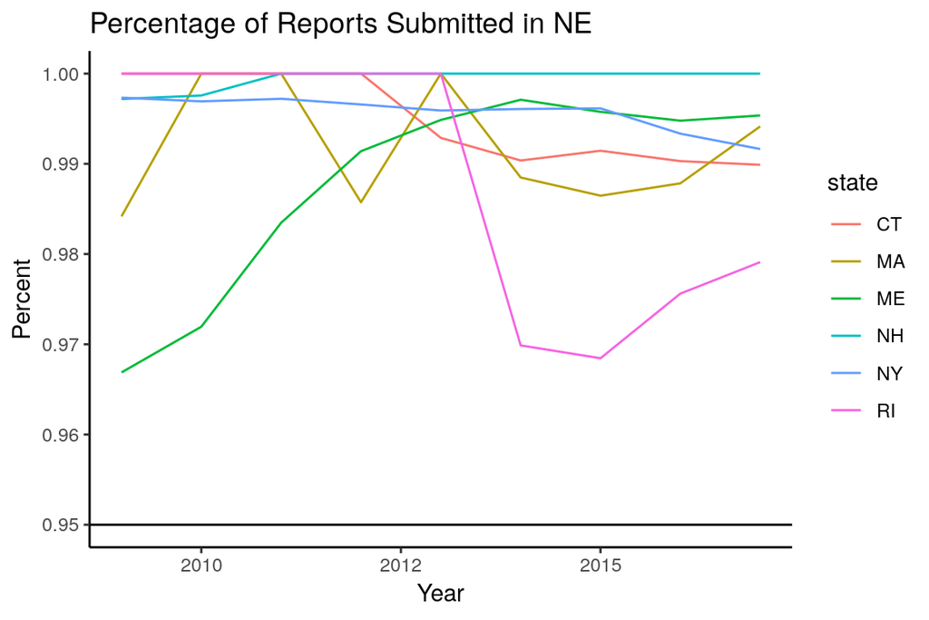

```r
dmr_sub_graph <- ggplot(dmr_submissions) +
  geom_line(aes(x= year, y= percent_submitted, color=state))+
  ggtitle("Percentage of Reports Submitted in NE") +
  ylab("Percent") +
  xlab("Year") +
  theme_classic() +
  geom_hline(yintercept=0.95)

dmr_sub_graph
```

```r
##save fig
#ggsave("figs/dmr_sub_graph.jpg", width=7, height=5, dpi=300)
```

Gapfilling for years 2005-2008

```r
y5 <- rep(2005, times= 6)
y6 <- rep(2006, times= 6)
y7 <- rep(2007, times= 6)
y8 <- rep(2008, times= 6)
year <- c(y5, y6, y7, y8)

state <- rep(c("ME", "NH", "MA", "RI", "CT", "NY"), times = 4)

gapfill <- cbind(year, state) %>%
  as.data.frame() %>%
  mutate(percent_submitted = case_when(
    state == "ME" ~ "0.9668811",
    state == "NH" ~ "0.9971842",
    state == "MA" ~ "0.9841761",
    state == "RI" ~ "1",
    state == "CT" ~ "1",
    state == "NY" ~ "0.9973308")) %>%
  select(percent_submitted, state, year) %>%
  mutate(percent_submitted = as.numeric(percent_submitted),
         year = as.character(year))

dmr_gapfill_submissions <- rbind(gapfill, dmr_submissions)  %>%
  mutate(year = as.numeric(year))

#write.csv(dmr_gapfilled,"data/dmr_gapfill_submissions.csv")
```

#**Compliance** ##Violations Percentage of facilities with compliance regualtions by year by state Note: not differentiating between types of violations (of which there are 4)

```r
violations_hist <- raw_report_history %>%
  mutate(state = substr(NPDES_ID, 0, 2),
         year = substr(YEARQTR, 0, 4))%>%
  filter(year >=2005 & year <=2017) %>%
  filter(state == "ME" | state == "NH" | state == "MA" | state =="RI" | state == "CT" | state == "NY") %>%
  mutate(violation = 1) %>% #can assign a 1 to all columns becuase all rows included here mean there was a violation of some sort
  select(year, state, NPDES_ID, violation) %>%
  distinct() %>%  # want to know if a violation that year, doesn't matter what quarter or if multiple violations in one year
  group_by(year, state) %>%
  count() %>%
  rename(fac_violations= n)
```

```r
## percent of facilities with violations by state

violations <- left_join(num_fac, violations_hist, by = c("year", "state"))%>%
  mutate(percent_w_violations = fac_violations/fac_total,
         percent_no_violation = 1- percent_w_violations) %>% #to avoid dividing by a target of 0 violationfor later score calculations
  mutate(year = as.numeric(year))

#save data
#write.csv(violations, "data/violations.csv")
```

Visualization

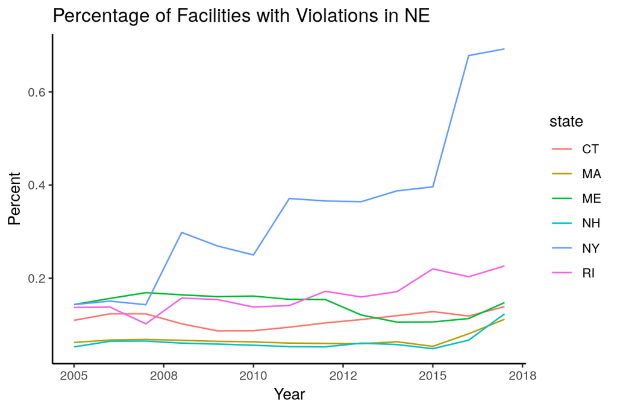

```r
violations_graph <- ggplot(violations) +
  geom_line(aes(x= year, y = percent_w_violations, color= state)) +
  ggtitle("Percentage of Facilities with Violations in NE") +
  ylab("Percent") +
  xlab("Year") +
  theme_classic()

violations_graph
```

```r
##save fig
#ggsave("figs/violations_graph.jpg", width=7, height=5, dpi=300)
```

#Creating a single data frame for water pollution resilience metric

```r
wp_res_metrics <- left_join(dmr_gapfill_submissions, violations, by = c("year", "state")) %>%
  left_join(.,facilities_inspected, by = c("year", "state")) %>%
  select(year, state, percent_submitted, percent_no_violation, percent_w_inspections)%>%
  mutate(target_inspections = 0.5,
         target_no_violations = 1,
         target_submitted = 0.95,
         target_regulation = 1,
         percent_regulation = 1) %>%
  select(year, state, percent_regulation, target_regulation, percent_submitted, target_submitted, percent_no_violation,target_no_violations, percent_w_inspections, target_inspections)

#write.csv(wp_res_metrics, "data/wp_res_metrics.csv")
```

Calculating Scores:

For the water pollution resilience scores (wp_res_scores) a score of 1 would be the best

4 equally weighted metrics used in the calculation: 1. Score of 1 for having regulations in place (ie: the EPA); no regulation would be 0 2. Score between 0-1 for inspections of discharge facilities. Calculated by taking the percent of facilities inspected at least once/the EPA’s target go 50%. If reached target a score of 1 would be acheived 3. Score between 0-1 for discharge facilitiy violations. Calculated by taking the percent of facilities that had no violations/ the EPA’s target of 100% no violations. If reached target a score of 1 would be acheived 4. Score between 0-1 for submissions of discharge monitoring reports (DMR). Calculated by taking the percent of DMRs submitted/ % the EPA’s target of 95% submission of expected DMRs. If reached target a score of 1 would be acheived

```r
wp_res_score <- wp_res_metrics %>%
  mutate(regulation_score = percent_regulation/target_regulation,
         inspection_score = percent_w_inspections/target_inspections,
         noviolation_score = percent_no_violation/target_no_violations,
         submitted_score = percent_submitted/target_submitted,
         submitted_score = if_else(submitted_score >1, 1, submitted_score)) %>%  # capping the score at 1
  select(year, state, regulation_score, inspection_score, noviolation_score, submitted_score) %>%
  group_by(year, state) %>%
  summarise(wp_res_score = sum(inspection_score, submitted_score, noviolation_score, regulation_score)/4)

#write.csv(wp_res_score, file = "wp_res_score")
```

Visualization

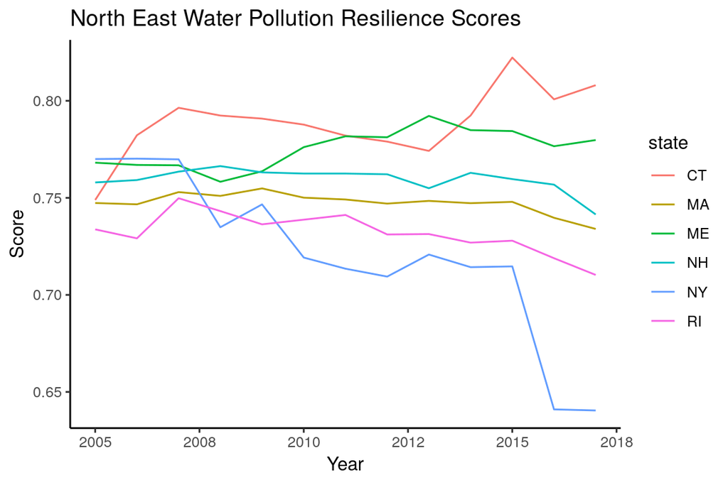

```r
wp_res_scores_graph <- ggplot(wp_res_score) +
  geom_line(aes(x=year, y= wp_res_score, color = state))+
  ggtitle("North East Water Pollution Resilience Scores") +
  ylab("Score") +
  xlab("Year") +
  theme_classic()

wp_res_scores_graph
```

```r
#ggsave("figs/wp_res_scores_graph.jpg", width=7, height=5, dpi=300)
```